# Exercise 7B Part Two

YOUR NAME

```r
library(tidyverse)
library(readxl)
library(janitor)
library(broom)
```

## Your turn: new data - fertility data

- Using the fertility data from the [gapminder web site](https://www.gapminder.org/data/) (in data/ folder)
- This contains data of number of babies born per woman
- You can find this out by exploring the data in the aforementioned gapminder website (https://www.gapminder.org/data/documentation/gd008/)
- Conduct the same analysis as in the gapminder example from the lecture ( ida-exercise-7b.Rmd), but for life expectancy.
- Find unusual countries

The code below will help you read in the data and process it, but you will need to make some changes to do the full analysis.

```r
fertility_raw <- read_xlsx(here::here(
  "Week7-Workshop2/ExtraPractice/data-raw/indicator-undata-total-fertility.xlsx"
  )) %>%
  clean_names() %>%
  rename(country = total_fertility_rate)

fertility_raw
```

```
## # A tibble: 260 x 217
##    country x1800_0 x1801_0 x1802_0 x1803_0 x1804_0 x1805_0 x1806_0 x1807_0
##    <chr>     <dbl>   <dbl>   <dbl>   <dbl>   <dbl>   <dbl>   <dbl>   <dbl>
##  1 Abkhaz…   NA      NA      NA      NA      NA      NA      NA      NA
##  2 Afghan…    7       7       7       7       7       7       7       7
##  3 Akroti…   NA      NA      NA      NA      NA      NA      NA      NA
##  4 Albania    4.6     4.6     4.6     4.6     4.6     4.6     4.6     4.6
##  5 Algeria    6.99    6.99    6.99    6.99    6.99    6.99    6.99    6.99
##  6 Americ…   NA      NA      NA      NA      NA      NA      NA      NA
##  7 Andorra   NA      NA      NA      NA      NA      NA      NA      NA
##  8 Angola     6.93    6.93    6.93    6.93    6.93    6.93    6.93    6.94
##  9 Anguil…   NA      NA      NA      NA      NA      NA      NA      NA
## 10 Antigu…    5       5       4.99    4.99    4.99    4.98    4.98    4.97
## # … with 250 more rows, and 208 more variables: x1808_0 <dbl>, x1809_0 <dbl>,
## #   x1810_0 <dbl>, x1811_0 <dbl>, x1812_0 <dbl>, x1813_0 <dbl>, x1814_0 <dbl>,
## #   x1815_0 <dbl>, x1816_0 <dbl>, x1817_0 <dbl>, x1818_0 <dbl>, x1819_0 <dbl>,
## #   x1820_0 <dbl>, x1821_0 <dbl>, x1822_0 <dbl>, x1823_0 <dbl>, x1824_0 <dbl>,
## #   x1825_0 <dbl>, x1826_0 <dbl>, x1827_0 <dbl>, x1828_0 <dbl>, x1829_0 <dbl>,
## #   x1830_0 <dbl>, x1831_0 <dbl>, x1832_0 <dbl>, x1833_0 <dbl>, x1834_0 <dbl>,
## #   x1835_0 <dbl>, x1836_0 <dbl>, x1837_0 <dbl>, x1838_0 <dbl>, x1839_0 <dbl>,
## #   x1840_0 <dbl>, x1841_0 <dbl>, x1842_0 <dbl>, x1843_0 <dbl>, x1844_0 <dbl>,
## #   x1845_0 <dbl>, x1846_0 <dbl>, x1847_0 <dbl>, x1848_0 <dbl>, x1849_0 <dbl>,
## #   x1850_0 <dbl>, x1851_0 <dbl>, x1852_0 <dbl>, x1853_0 <dbl>, x1854_0 <dbl>,
## #   x1855_0 <dbl>, x1856_0 <dbl>, x1857_0 <dbl>, x1858_0 <dbl>, x1859_0 <dbl>,
## #   x1860_0 <dbl>, x1861_0 <dbl>, x1862_0 <dbl>, x1863_0 <dbl>, x1864_0 <dbl>,
## #   x1865_0 <dbl>, x1866_0 <dbl>, x1867_0 <dbl>, x1868_0 <dbl>, x1869_0 <dbl>,
## #   x1870_0 <dbl>, x1871_0 <dbl>, x1872_0 <dbl>, x1873_0 <dbl>, x1874_0 <dbl>,
## #   x1875_0 <dbl>, x1876_0 <dbl>, x1877_0 <dbl>, x1878_0 <dbl>, x1879_0 <dbl>,
## #   x1880_0 <dbl>, x1881_0 <dbl>, x1882_0 <dbl>, x1883_0 <dbl>, x1884_0 <dbl>,
## #   x1885_0 <dbl>, x1886_0 <dbl>, x1887_0 <dbl>, x1888_0 <dbl>, x1889_0 <dbl>,
## #   x1890_0 <dbl>, x1891_0 <dbl>, x1892_0 <dbl>, x1893_0 <dbl>, x1894_0 <dbl>,
## #   x1895_0 <dbl>, x1896_0 <dbl>, x1897_0 <dbl>, x1898_0 <dbl>, x1899_0 <dbl>,
## #   x1900_0 <dbl>, x1901_0 <dbl>, x1902_0 <dbl>, x1903_0 <dbl>, x1904_0 <dbl>,
## #   x1905_0 <dbl>, x1906_0 <dbl>, x1907_0 <dbl>, …
```

You will need to pivot the data into longer form, using the `pivot_longer` function.

You should know how to do the rest from your experience with past assignments.

```r
fertility <-
  fertility_raw %>%
  pivot_longer(cols = -country, # everything but country,
               # what is the name of the new variable we are changing the
               # column of names to?
               names_to = "year_collected",
               # What is the name of the column we are changing the values to?
               values_to = "babies_per_woman") %>%
  #extract out the year information
  mutate(year = parse_number(year_collected)) %>%
  # filter so we only look at years above 1950
  filter( year > 1950) %>%
  # center year around 1950
  na.omit %>%
  mutate(year1950 = year - 1950)
```

plot the fertility data for each year

```r
ggplot(fertility,
       aes(x = year,
           y = babies_per_woman,
           group = country)) +
  geom_line(alpha=0.1)
```

[output not shown]

Now try and answer these questions below. You can use the examples in `ida-exercise-7b.Rmd` to help you answer these questions.

# How has fertility changed over years? For each country?

A little decrease can be seen Major dips after 1980

## How has fertility changed in Australia?

```r
oz <- fertility %>% filter(country == "Australia")

oz
```

```
## # A tibble: 65 x 5
##    country   year_collected babies_per_woman  year year1950
##    <chr>     <chr>                     <dbl> <dbl>    <dbl>
##  1 Australia x1951_0                    3.06  1951        1
##  2 Australia x1952_0                    3.18  1952        2
##  3 Australia x1953_0                    3.19  1953        3
##  4 Australia x1954_0                    3.19  1954        4
##  5 Australia x1955_0                    3.28  1955        5
##  6 Australia x1956_0                    3.33  1956        6
##  7 Australia x1957_0                    3.42  1957        7
##  8 Australia x1958_0                    3.42  1958        8
##  9 Australia x1959_0                    3.44  1959        9
## 10 Australia x1960_0                    3.45  1960       10
## # … with 55 more rows
```

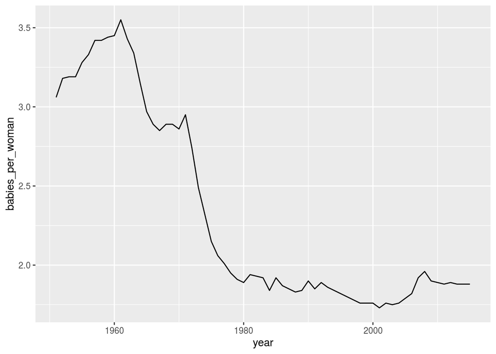

```r
ggplot(data = oz,
       aes(x = year,
           y = babies_per_woman)) +
  geom_line()
```

Dip after 1960.

## Fit a model for Australia

```r
oz_lm <- lm(babies_per_woman ~ year, data = oz)

oz_lm
```

```
##
## Call:
## lm(formula = babies_per_woman ~ year, data = oz)
##
## Coefficients:
## (Intercept)         year
##    59.48619     -0.02883
```

```r
summary(oz_lm)
```

```
##
## Call:
## lm(formula = babies_per_woman ~ year, data = oz)
##
## Residuals:
##      Min       1Q   Median       3Q      Max
## -0.52685 -0.24092  0.00364  0.28253  0.59426
##
## Coefficients:
##              Estimate Std. Error t value Pr(>|t|)
## (Intercept) 59.486194   4.168165   14.27   <2e-16 ***
## year        -0.028827   0.002102  -13.71   <2e-16 ***
## ---
## Signif. codes:  0 '***' 0.001 '**' 0.01 '*' 0.05 '.' 0.1 ' ' 1
##
## Residual standard error: 0.3179 on 63 degrees of freedom
## Multiple R-squared:  0.7491, Adjusted R-squared:  0.7451
## F-statistic: 188.1 on 1 and 63 DF,  p-value: < 2.2e-16
```

```r
oz_aug <- augment(oz_lm, oz)

oz_aug
```

```
## # A tibble: 65 x 11
##    country year_collected babies_per_woman  year year1950 .fitted   .resid
##    <chr>   <chr>                     <dbl> <dbl>    <dbl>   <dbl>    <dbl>
##  1 Austra… x1951_0                    3.06  1951        1    3.24 -0.184
##  2 Austra… x1952_0                    3.18  1952        2    3.22 -0.0352
##  3 Austra… x1953_0                    3.19  1953        3    3.19  0.00364
##  4 Austra… x1954_0                    3.19  1954        4    3.16  0.0325
##  5 Austra… x1955_0                    3.28  1955        5    3.13  0.151
##  6 Austra… x1956_0                    3.33  1956        6    3.10  0.230
##  7 Austra… x1957_0                    3.42  1957        7    3.07  0.349
##  8 Austra… x1958_0                    3.42  1958        8    3.04  0.378
##  9 Austra… x1959_0                    3.44  1959        9    3.01  0.427
## 10 Austra… x1960_0                    3.45  1960       10    2.98  0.465
## # … with 55 more rows, and 4 more variables: .std.resid <dbl>, .hat <dbl>,
## #   .sigma <dbl>, .cooksd <dbl>
```

## Explore model fit for Australia

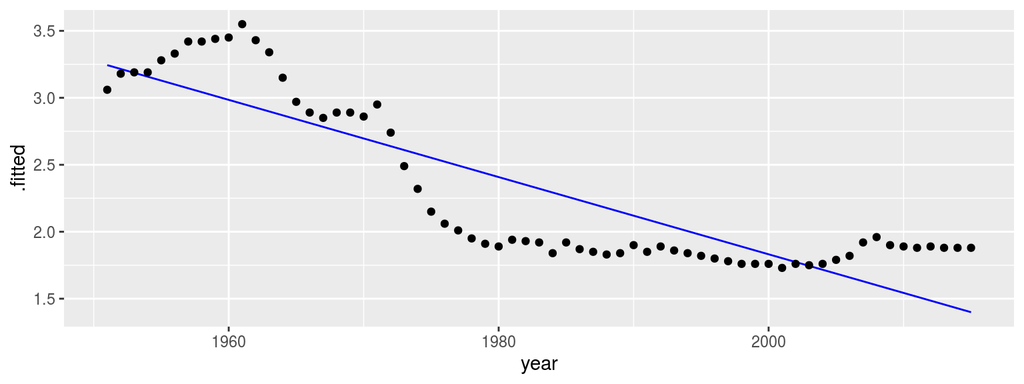

```r
ggplot(data = oz_aug,
       aes(x = year,
           y = .fitted)) +
  geom_line(colour = "blue") +
  geom_point(aes(x = year,
                 y = babies_per_woman))
```

In Australia, for a unit inctrease in year, the ferility has decreased by -0.02883 on average 74.91% variance is explanined by this model.

for a unit inctrease in year, the ferility has decreased by -0.02883 on average. The increase prior to 1960, isn’t explained by this model.

## How well does the model fit?

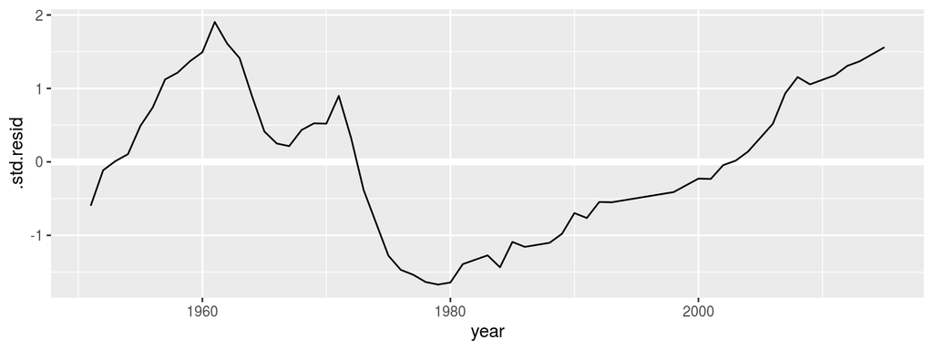

```r
ggplot(data = oz_aug,
             aes(x = year,
                 y = .std.resid)) +
  geom_hline(yintercept = 0,
             colour = "white",
             size = 2) +
  geom_line()
```

## Fit a linear model for all countries

```r
by_country <- fertility %>%
  select(country, year1950, babies_per_woman) %>%
  group_by(country) %>%
  nest()

by_country
```

```
## # A tibble: 201 x 2
## # Groups:   country [201]
##    country             data
##    <chr>               <list>
##  1 Afghanistan         <tibble [65 × 2]>
##  2 Albania             <tibble [65 × 2]>
##  3 Algeria             <tibble [65 × 2]>
##  4 Angola              <tibble [65 × 2]>
##  5 Antigua and Barbuda <tibble [65 × 2]>
##  6 Argentina           <tibble [65 × 2]>
##  7 Armenia             <tibble [65 × 2]>
##  8 Aruba               <tibble [65 × 2]>
##  9 Australia           <tibble [65 × 2]>
## 10 Austria             <tibble [65 × 2]>
## # … with 191 more rows
```

```r
mapped_lm <-map(by_country$data, function(x){
  lm(babies_per_woman ~ year1950, data = x)
  })

mapped_lm
```

```
## [[1]]
##
## Call:
## lm(formula = babies_per_woman ~ year1950, data = x)
##
## Coefficients:
## (Intercept)     year1950
##     8.23765     -0.02732
##
##
## [[2]]
##
## Call:
## lm(formula = babies_per_woman ~ year1950, data = x)
##
## Coefficients:
## (Intercept)     year1950
##     6.60451     -0.08433
##
##
## [[3]]
##
## Call:
## lm(formula = babies_per_woman ~ year1950, data = x)
##
## Coefficients:
## (Intercept)     year1950
##      9.0654      -0.1077
##
##
## [[4]]
##
## Call:
## lm(formula = babies_per_woman ~ year1950, data = x)
##
## Coefficients:
## (Intercept)     year1950
##     7.54258     -0.01679
##
##
```

[output cut: 1953 more lines]

```
## lm(formula = babies_per_woman ~ year1950, data = x)
##
## Coefficients:
## (Intercept)     year1950
##     7.50106     -0.02554
##
##
## [[201]]
##
## Call:
## lm(formula = babies_per_woman ~ year1950, data = x)
##
## Coefficients:
## (Intercept)     year1950
##     8.20615     -0.07233
```

# Map inside data

```r
country_model <- by_country %>%
  mutate(model = map(data, function(x){
    lm(babies_per_woman ~ year1950, data = x)
    })
    )

country_model
```

```
## # A tibble: 201 x 3
## # Groups:   country [201]
##    country             data              model
##    <chr>               <list>            <list>
##  1 Afghanistan         <tibble [65 × 2]> <lm>
##  2 Albania             <tibble [65 × 2]> <lm>
##  3 Algeria             <tibble [65 × 2]> <lm>
##  4 Angola              <tibble [65 × 2]> <lm>
##  5 Antigua and Barbuda <tibble [65 × 2]> <lm>
##  6 Argentina           <tibble [65 × 2]> <lm>
##  7 Armenia             <tibble [65 × 2]> <lm>
##  8 Aruba               <tibble [65 × 2]> <lm>
##  9 Australia           <tibble [65 × 2]> <lm>
## 10 Austria             <tibble [65 × 2]> <lm>
## # … with 191 more rows
```

```r
country_model <- by_country %>%
  mutate(model = map(data, ~lm(babies_per_woman ~ year1950, data = .)))

country_model
```

```
## # A tibble: 201 x 3
## # Groups:   country [201]
##    country             data              model
##    <chr>               <list>            <list>
##  1 Afghanistan         <tibble [65 × 2]> <lm>
##  2 Albania             <tibble [65 × 2]> <lm>
##  3 Algeria             <tibble [65 × 2]> <lm>
##  4 Angola              <tibble [65 × 2]> <lm>
##  5 Antigua and Barbuda <tibble [65 × 2]> <lm>
##  6 Argentina           <tibble [65 × 2]> <lm>
##  7 Armenia             <tibble [65 × 2]> <lm>
##  8 Aruba               <tibble [65 × 2]> <lm>
##  9 Australia           <tibble [65 × 2]> <lm>
## 10 Austria             <tibble [65 × 2]> <lm>
## # … with 191 more rows
```

```r
country_model %>%
  mutate(tidy = map(model, tidy))
```

```
## # A tibble: 201 x 4
## # Groups:   country [201]
##    country             data              model  tidy
##    <chr>               <list>            <list> <list>
##  1 Afghanistan         <tibble [65 × 2]> <lm>   <tibble [2 × 5]>
##  2 Albania             <tibble [65 × 2]> <lm>   <tibble [2 × 5]>
##  3 Algeria             <tibble [65 × 2]> <lm>   <tibble [2 × 5]>
##  4 Angola              <tibble [65 × 2]> <lm>   <tibble [2 × 5]>
##  5 Antigua and Barbuda <tibble [65 × 2]> <lm>   <tibble [2 × 5]>
##  6 Argentina           <tibble [65 × 2]> <lm>   <tibble [2 × 5]>
##  7 Armenia             <tibble [65 × 2]> <lm>   <tibble [2 × 5]>
##  8 Aruba               <tibble [65 × 2]> <lm>   <tibble [2 × 5]>
##  9 Australia           <tibble [65 × 2]> <lm>   <tibble [2 × 5]>
## 10 Austria             <tibble [65 × 2]> <lm>   <tibble [2 × 5]>
## # … with 191 more rows
```

```r
country_coefs <- country_model %>%
  mutate(tidy = map(model, tidy)) %>%
  unnest(tidy) %>%
  select(country, term, estimate)

country_coefs
```

```
## # A tibble: 402 x 3
## # Groups:   country [201]
##    country             term        estimate
##    <chr>               <chr>          <dbl>
##  1 Afghanistan         (Intercept)   8.24
##  2 Afghanistan         year1950     -0.0273
##  3 Albania             (Intercept)   6.60
##  4 Albania             year1950     -0.0843
##  5 Algeria             (Intercept)   9.07
##  6 Algeria             year1950     -0.108
##  7 Angola              (Intercept)   7.54
##  8 Angola              year1950     -0.0168
##  9 Antigua and Barbuda (Intercept)   4.40
## 10 Antigua and Barbuda year1950     -0.0453
## # … with 392 more rows
```

```r
tidy_country_coefs <- country_coefs %>%
  pivot_wider(id_cols = c(term, country),
              names_from =  term,
              values_from = estimate) %>%
  rename(intercept = `(Intercept)`)

tidy_country_coefs
```

```
## # A tibble: 201 x 3
## # Groups:   country [201]
##    country             intercept year1950
##    <chr>                   <dbl>    <dbl>
##  1 Afghanistan              8.24  -0.0273
##  2 Albania                  6.60  -0.0843
##  3 Algeria                  9.07  -0.108
##  4 Angola                   7.54  -0.0168
##  5 Antigua and Barbuda      4.40  -0.0453
##  6 Argentina                3.44  -0.0171
##  7 Armenia                  4.62  -0.0579
##  8 Aruba                    4.87  -0.0607
##  9 Australia                3.27  -0.0288
## 10 Austria                  2.56  -0.0221
## # … with 191 more rows
```

```r
tidy_country_coefs %>%
  filter(country == "Australia")
```

```
## # A tibble: 1 x 3
## # Groups:   country [1]
##   country   intercept year1950
##   <chr>         <dbl>    <dbl>
## 1 Australia      3.27  -0.0288
```

# Plot all models

```r
country_aug <- country_model %>%
  mutate(augmented = map(model, augment)) %>%
  unnest(augmented)

country_aug
```

```
## # A tibble: 13,061 x 11
## # Groups:   country [201]
##    country data  model babies_per_woman year1950 .fitted .resid .std.resid
##    <chr>   <lis> <lis>            <dbl>    <dbl>   <dbl>  <dbl>      <dbl>
##  1 Afghan… <tib… <lm>              7.67        1    8.21 -0.540     -0.853
##  2 Afghan… <tib… <lm>              7.67        2    8.18 -0.513     -0.809
##  3 Afghan… <tib… <lm>              7.67        3    8.16 -0.486     -0.765
##  4 Afghan… <tib… <lm>              7.67        4    8.13 -0.458     -0.721
##  5 Afghan… <tib… <lm>              7.67        5    8.10 -0.431     -0.677
##  6 Afghan… <tib… <lm>              7.67        6    8.07 -0.404     -0.633
##  7 Afghan… <tib… <lm>              7.67        7    8.05 -0.376     -0.589
##  8 Afghan… <tib… <lm>              7.67        8    8.02 -0.349     -0.546
##  9 Afghan… <tib… <lm>              7.67        9    7.99 -0.322     -0.503
## 10 Afghan… <tib… <lm>              7.67       10    7.96 -0.294     -0.460
## # … with 13,051 more rows, and 3 more variables: .hat <dbl>, .sigma <dbl>,
## #   .cooksd <dbl>
```

## Plot the model fit against the data in two plots

```r
p1 <- fertility %>%
  ggplot(aes(year, babies_per_woman, group = country)) +
    geom_line(alpha = 1/3) + ggtitle("Data")

p2 <- ggplot(country_aug) +
  geom_line(aes(x = year1950 + 1950,
                y = .fitted,
                group = country),
            alpha = 1/3) +
  xlab("year") +
  ggtitle("Fitted models")
```

```r
library(gridExtra)
```

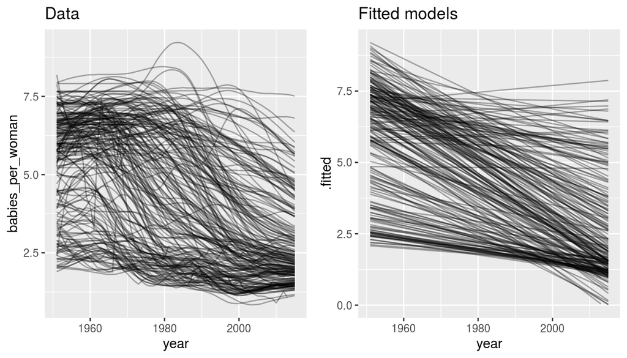

```r
grid.arrange(p1, p2, ncol=2)
```